# Compare and evaluate bird model predictions for the Hudson bay lowlands

Sarah Endicott

2024-01-15

#### Notes on differences between the models:

The Bateman 2020 models are SDMs that predict habitat suitability, the BAM national models predict density in number of signing males per ha and the ebird models predict “relative abundance” defined as the the count by an expert eBirder on a 1 hour, 2 kilometer traveling checklist at the optimal time of day. The eBird models also don’t make predictions in areas where there was < 0.05% spatial coverage in a 3km grid cell.

Maps show the prediction rasters for each species. The first set of graphs compare the values from each model at 1000 points using four different measures. Prediction is the raw value, scaled_pred is the prediction divided by the root-mean-square, rank_pred is the rank of each value relative to other sampled points after removing points that are NA for any model, and rank_sd gives the standard deviation of ranks across models for each point. Points were projected on the fly to avoid re-projecting the rasters.

The second set of graphs compare mean observed abundance across multiple recordings from the same location to the model predictions. I know that this doesn’t fully make sense because the predictions are in different units and were trained on differently prepared data but I figured we would still expect them to be correlated or somewhat related as a starting point.

The first table gives the mean of the rank_sds at each sample point for each species. The second table gives model performance measures for the validation data. corr, intercept, slope, r.squared, and nobs for a linear model of mean observed abundance ~ prediction. auc and rmse use the binary observation data and the model predictions. For the same reasons mentioned above this is just a starting point.

## aldfly

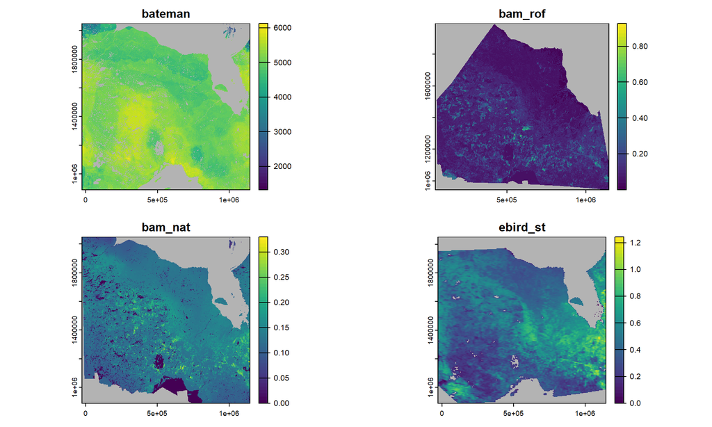

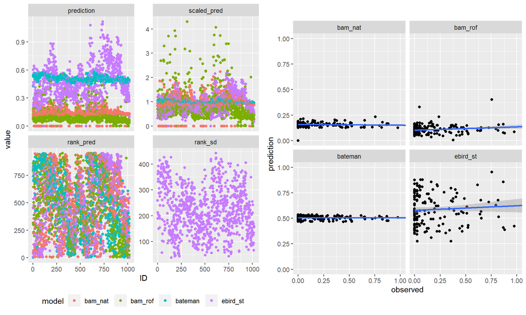

## amecro

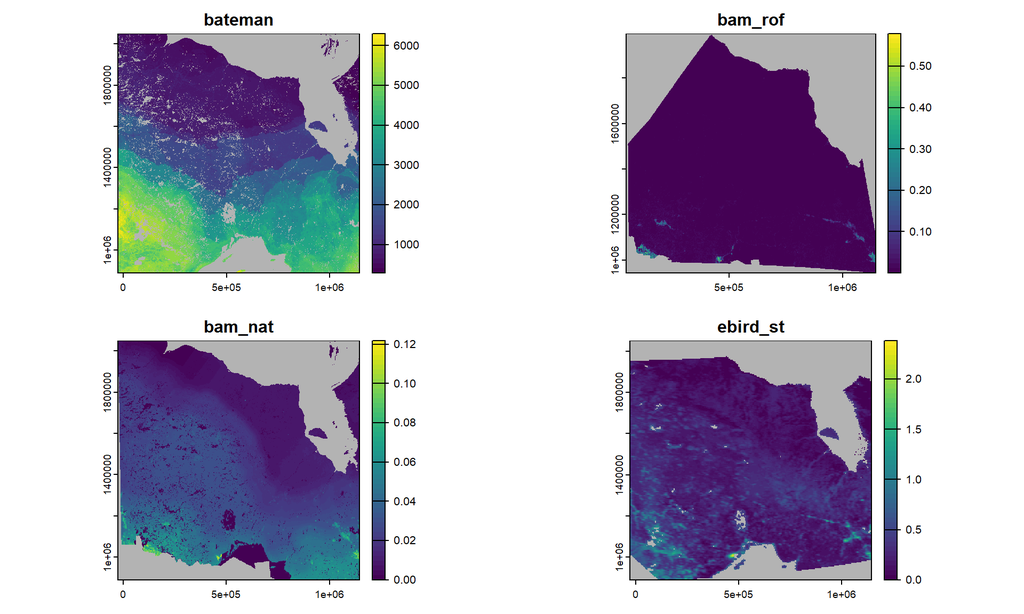

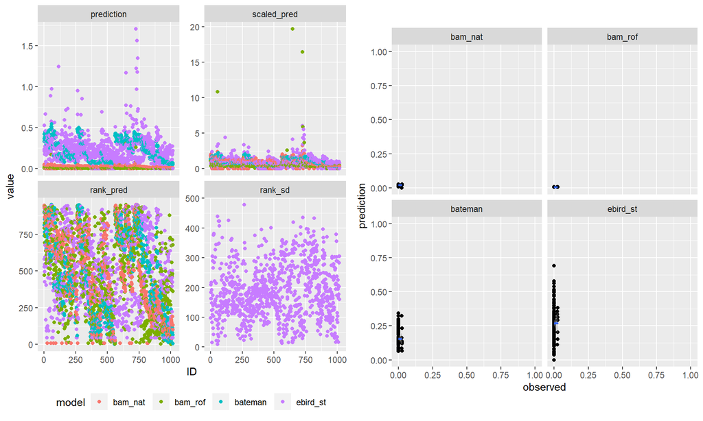

## Tables

|  | sp4 | sp6 | mean_rank_sd |
| --- | --- | --- | --- |
| 1 | ALFL | aldfly | 220.82 |
| 2 | AMCR | amecro | 187.98 |

|  | model | sp4 | sp6 | corr | intercept | slope | r.squared | nobs | auc | rmse |
| --- | --- | --- | --- | --- | --- | --- | --- | --- | --- | --- |
| 1 | bam_nat | ALFL | aldfly | -0.093 | 0.408 | -1.276 | 0.009 | 172 | 0.454 | 0.593 |
| 2 | bam_rof | ALFL | aldfly | 0.211 | 0.063 | 1.338 | 0.045 | 172 | 0.538 | 0.595 |
| 3 | bateman | ALFL | aldfly | -0.024 | 0.389 | -0.351 | 0.001 | 168 | 0.454 | 0.663 |
| 4 | ebird_st | ALFL | aldfly | 0.089 | 0.107 | 0.173 | 0.008 | 172 | 0.495 | 0.711 |
| 5 | bam_nat | AMCR | amecro | -0.01 | 0.002 | -0.017 | 0 | 172 | 0.645 | 0.042 |
| 6 | bam_rof | AMCR | amecro | 0.036 | -0.001 | 0.38 | 0.001 | 172 | 0.515 | 0.038 |
| 7 | bateman | AMCR | amecro | -0.004 | 0.001 | 0 | 0 | 168 | 0.528 | 0.171 |
| 8 | ebird_st | AMCR | amecro | 0.006 | 0.001 | 0 | 0 | 172 | 0.542 | 0.3 |